# DV(1-3) HW

Author

Carter Wyatt

## Question 1

```r
library(tidyverse)
# Read in the data
exercise_data <- read_csv("https://raw.githubusercontent.com/vaiseys/dav-course/main/Data/visualize_data.csv")
```

```
──────────────────────────────────────────────────────── Delimiter: "," dbl
(4): ...1, ...2, Exercise, BMI
```

```r
glimpse(exercise_data)
```

```
Rows: 142
Columns: 4
$ ...1     <dbl> 1, 2, 3, 4, 5, 6, 7, 8, 9, 10, 11, 12, 13, 14, 15, 16, 17, 18…
$ ...2     <dbl> 1, 2, 3, 4, 5, 6, 7, 8, 9, 10, 11, 12, 13, 14, 15, 16, 17, 18…
$ Exercise <dbl> 55.3846, 51.5385, 46.1538, 42.8205, 40.7692, 38.7179, 35.6410…
$ BMI      <dbl> 1.8320590, 1.7892194, 1.7321050, 1.6178724, 1.5036362, 1.3751…
```

Before, we see examine anything from the data, write down what you expect the relationship would look like. Do you think people who record more exercise will have more or less BMI?

I expect the relationship to look like BMI will be directly affected by exercise. I think people who record more exercise will have less BMI.

Run the following code and tell me what the output indicates.

```r
cor(exercise_data$Exercise, exercise_data$BMI)
```

```
[1] -0.06447185
```

Let’s explore this relationship visually. Make a scatterplot with exercise in the x axis and BMI in the y axis.

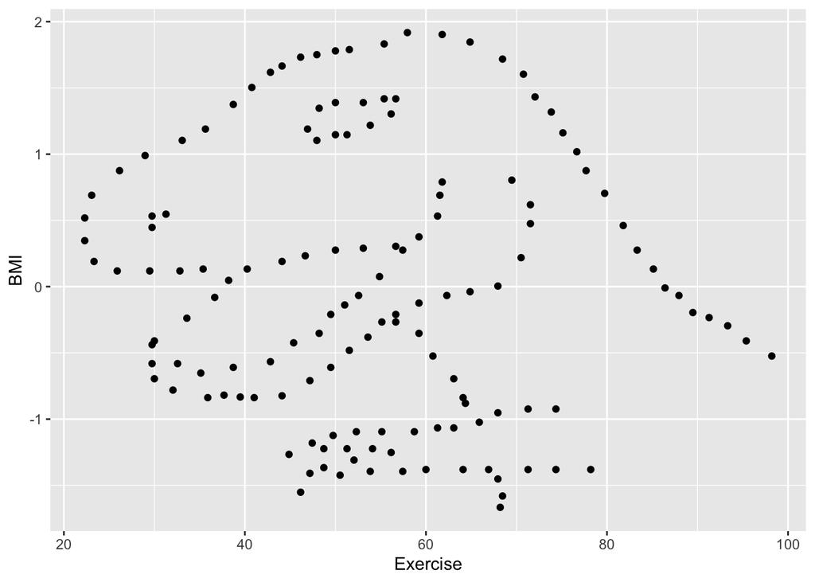

```r
 exercise_data |>
   ggplot(aes(x = Exercise,
            y = BMI)) + geom_point()
```

## Question 2

```r
install.packages("causact", repos = "http://cran.us.r-project.org")
```

```r
library(causact)
(corruptDF)
```

```
# A tibble: 174 × 7
   country     region          countryCode regionCode population CPI2017 HDI2017
   <chr>       <chr>           <chr>       <chr>           <int>   <int>   <dbl>
 1 Afghanistan Asia Pacific    AFG         AP           35530081      15   0.498
 2 Albania     East EU Cemt A… ALB         ECA           2873457      38   0.785
 3 Algeria     MENA            DZA         MENA         41318142      33   0.754
 4 Angola      SSA             AGO         SSA          29784193      19   0.581
 5 Argentina   Americas        ARG         AME          44271041      39   0.825
 6 Armenia     East EU Cemt A… ARM         ECA           2930450      35   0.755
 7 Australia   Asia Pacific    AUS         AP           24598933      77   0.939
 8 Austria     EU W. Europe    AUT         WE/EU         8809212      75   0.908
 9 Azerbaijan  East EU Cemt A… AZE         ECA           9862429      31   0.757
10 Bahamas     Americas        BHS         AME            395361      65   0.807
# ℹ 164 more rows
```

```r
?corruptDF
```

CPI2017 captures how corrupt a country is in the year 2017 from a scale from 0 which is the worst, and 100 which is the best.

HDI2017 captures how well-developed a country is compared to other countries in the year 2017 based on their longevity, education, and income.

## Question 3

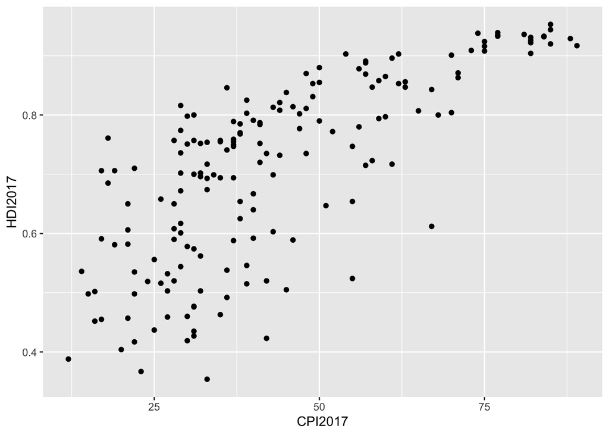

```r
 corruptDF |>
   ggplot(aes(x = CPI2017,
            y = HDI2017)) + geom_point()
```

Describe the relationship that you see.

## Question 4

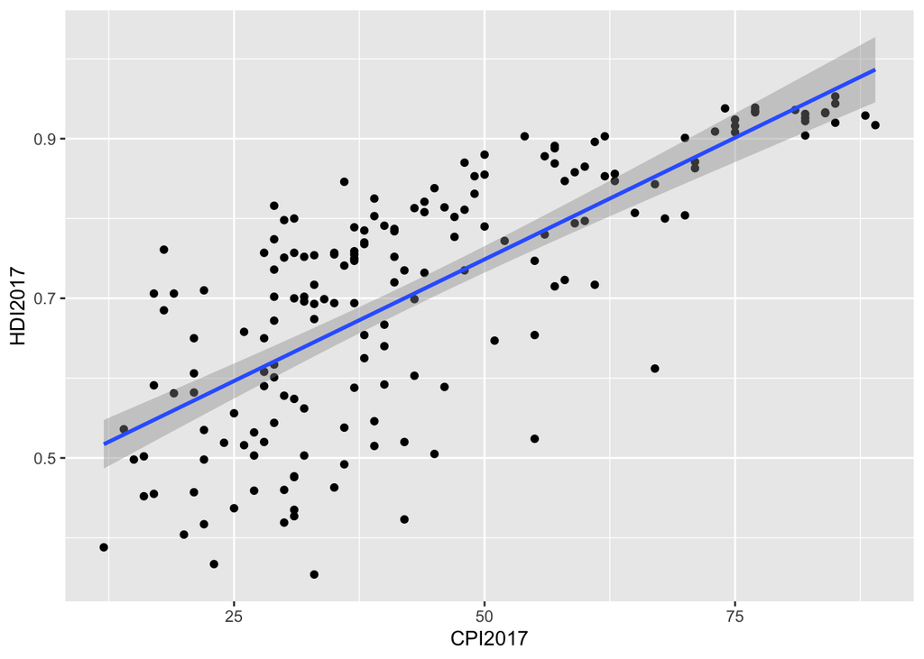

```r
corruptDF |>
   ggplot(aes(x = CPI2017,
            y = HDI2017)) + geom_point() +
  geom_smooth(method = "lm")
```

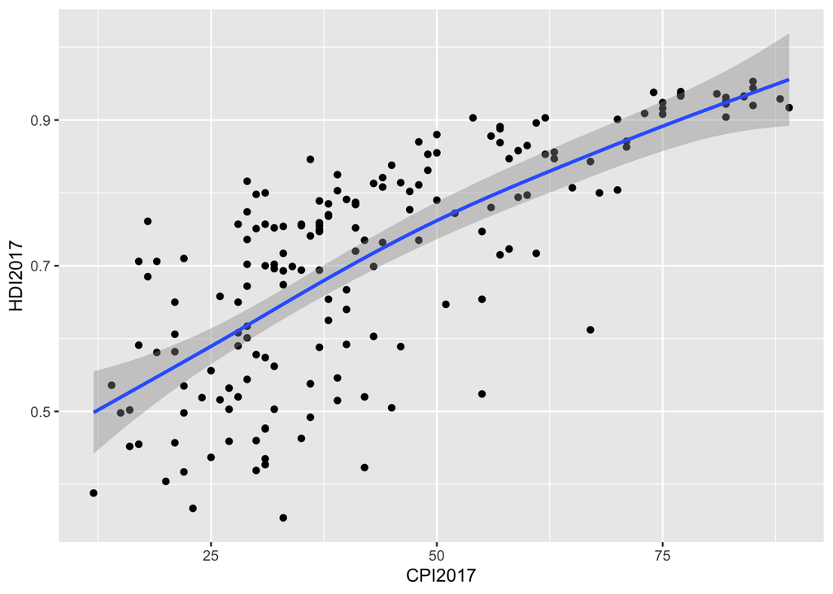

```r
corruptDF |>
   ggplot(aes(x = CPI2017,
            y = HDI2017)) + geom_point() +
  geom_smooth(method = "gam")
```

What are the differences? Which one do you prefer?

The differences is that in “lm” the data has less scatterplot dots on the shaded line on the linear expression as the shaded line in the linear expression is much thicker in “gam”. I personally prefer “lm” because I feel as it is easier to interpret and it is more aesthetically pleasing.

## Question 5

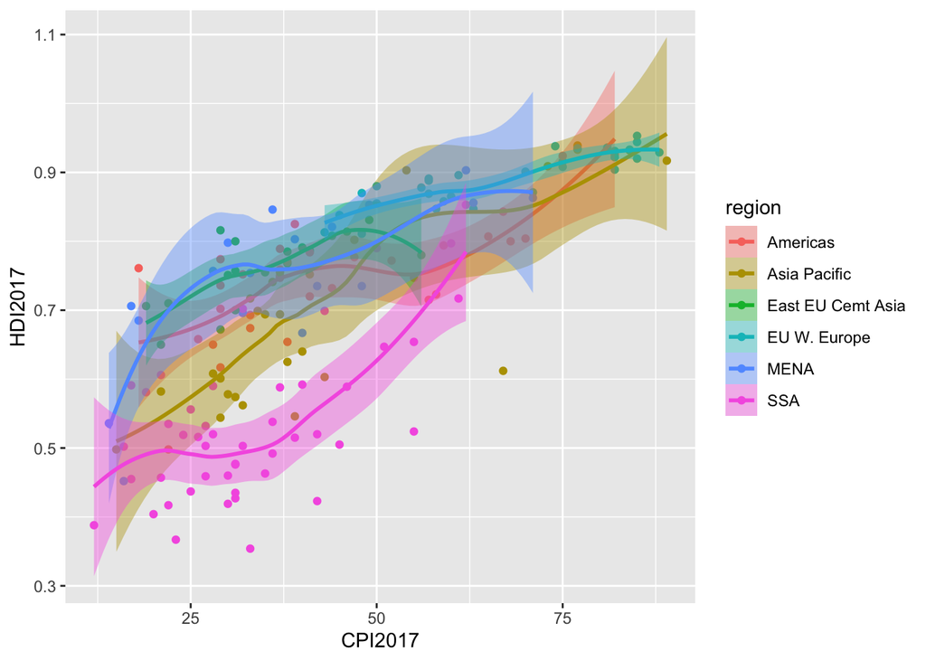

```r
corruptDF |>
   ggplot(aes(x = CPI2017,
            y = HDI2017, fill = region, color = region )) + geom_point() + geom_smooth()
```

What do you see?

I now see a legend of different regions that are all separated by color.

Are patterns clear or is the graph too cluttered?

The patterns on the graph are way too cluttered and it is an absolute mess that is hard to read.

What would be another way to get these trends by region but in a way to would be more legible?

If we were to facet_wrap the data then it would be broken into different categories and allow us to read the data by region, but separate graphs.

## Question 6

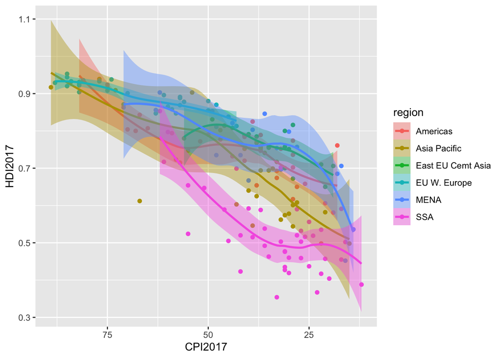

```r
corruptDF |>
   ggplot(aes(x = CPI2017,
            y = HDI2017, fill = region, color = region )) + geom_point() + geom_smooth() +
scale_x_reverse()
```

The line was just completely reversed and flipped for the graph.

## Question 7

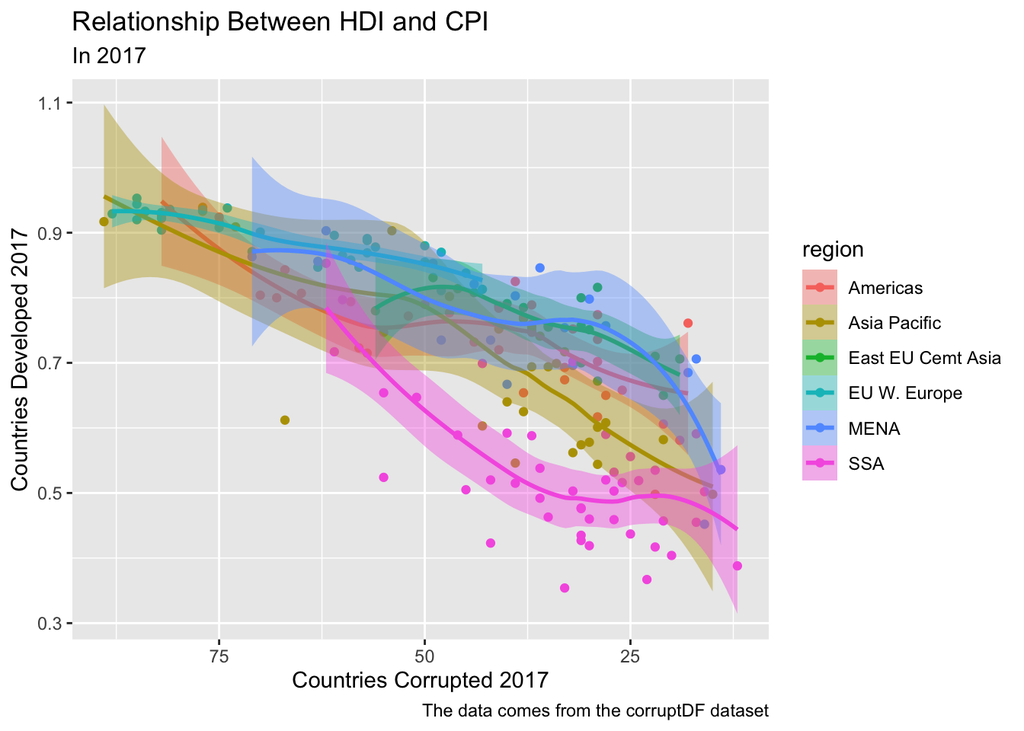

```r
corruptDF |>
   ggplot(aes(x = CPI2017,
            y = HDI2017, fill = region, color = region )) + geom_point() + geom_smooth() +
scale_x_reverse() +
  labs(x = "Countries Corrupted 2017", y = "Countries Developed 2017", title = "Relationship Between HDI and CPI", subtitle = "In 2017", caption = "The data comes from the corruptDF dataset")
```

## Question 8

```r
ggsave("HDI_CPI_2017.pdf")
```

The data should be all saved!

(I was unsure if we were supposed to leave the data from question 5 on when we were instructed to add things to our graph and then add things we learned from Healy in Q6).